# Geodesic Pathwise Polynomial Annihilator Experiments

## Purpose

This report evaluates an experimental graph operator intended to annihilate intrinsic low-degree polynomials by sampling geodesic paths in local graph disks. For a weighted graph, the disk around vertex $v$ is

$$B_G(v,\varepsilon)=\{u\in V : d_G(u,v)\le \varepsilon\},$$

where $d_G$ is graph-geodesic distance. The implementation samples composite geodesic paths through $v$, constructs one-dimensional polynomial annihilator rows along those paths, and stacks the rows into a sparse matrix $A$. If the construction behaves as an intrinsic polynomial annihilator on a sampled surface, then sampled intrinsic polynomials $p$ of degree at most $d$ should satisfy approximately

$$A p \approx 0.$$

The experiments ask two questions. First, on sampled $[0,1]^2$, does the estimated nullity of $A$ stabilize near the dimensions

$$\dim \mathcal P_{\le d}(\mathbb R^2)=\binom{d+2}{2}=3,6,10
\quad\text{for}\quad d=1,2,3?$$

Second, on sampled quadrics, does the operator respond to intrinsic polynomial structure in the surface parameters rather than merely to ambient coordinate polynomials in $(X,Y,Z)$?

The graph families tested here are the Delaunay 1-skeleton, symmetric kNN, radius graphs, and cKNN graphs. Two radius rules are compared. The fixed rule uses the graph distance to the $k_{\mathrm{disk}}$-th graph-geodesic neighbor. The adaptive rule increases $k_{\mathrm{disk}}$ until the number of available composite geodesics reaches a specified minimum, or until a maximum search size is reached. Detailed run tables and reproducibility code are collected in the appendix so the main text can focus on the figures.

## Disk Size

The disk radius controls what local geometry the operator sees. If disks are too small, there may be too few usable geodesic paths to identify multivariate polynomial structure. If disks are too large, the operator may mix geometry from regions where a local polynomial approximation is no longer appropriate. The first diagnostic therefore measures the distribution of

$$|B_G(v,\varepsilon_v)|$$

across vertices. Under the adaptive rule, $\varepsilon_v$ is selected as

$$\varepsilon_v
=\min \{\varepsilon_{v,k}: |\Gamma(v,\varepsilon_{v,k})|\ge m_{\min}\},$$

subject to the maximum allowed search size.

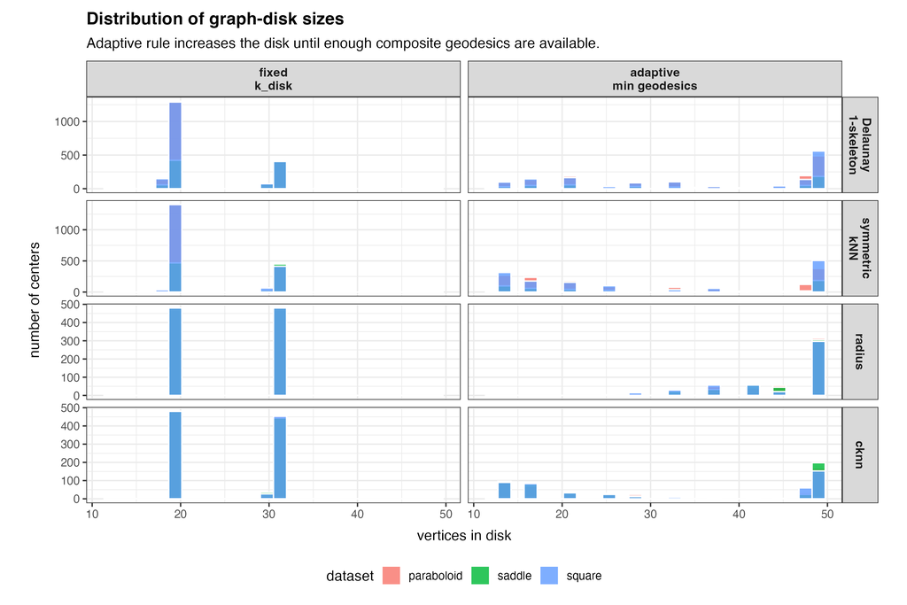

The adaptive rule often selects larger local disks than the fixed rule. This is expected: it is no longer trying to equalize disk size, but instead to guarantee a minimum supply of usable composite geodesics. The figure also shows that the extra disk growth is graph-dependent, which means the selected radius itself is an important diagnostic of local graph geometry.

## Selected Radius Search Size

The adaptive rule changes the radius by increasing the neighbor index $k_{\mathrm{disk}}$. The selected value is

$$k_v^\star=\min\{k: |\Gamma(v,\varepsilon_{v,k})|\ge m_{\min}\}.$$

If $k_v^\star$ is frequently near the maximum allowed value, the graph does not provide enough local composite geodesics at the tested scale.

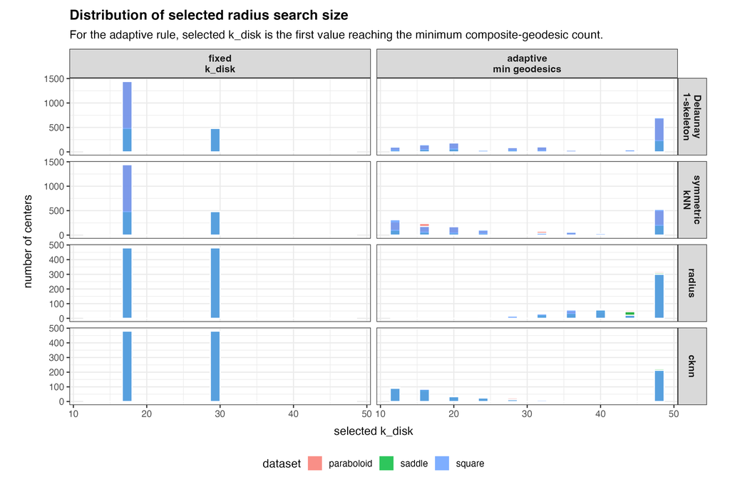

The selected-$k_{\mathrm{disk}}$ distributions show how much each graph family must expand its local disk to obtain enough composite geodesics. A concentration at small values means the local graph already supplies adequate path geometry. A heavy right tail means the graph requires larger neighborhoods before the operator can even be assembled with the requested path availability.

## Composite-Geodesic Availability

The operator is built from pathwise annihilator rows. The relevant local sample size is therefore not just the disk size but the number of composite geodesics available through each center vertex. For each center $v$, we count candidate paths $\gamma\in\Gamma(v,\varepsilon_v)$ that pass through $v$ and satisfy the composite-geodesic test. This diagnostic measures

$$|\Gamma(v,\varepsilon_v)|.$$

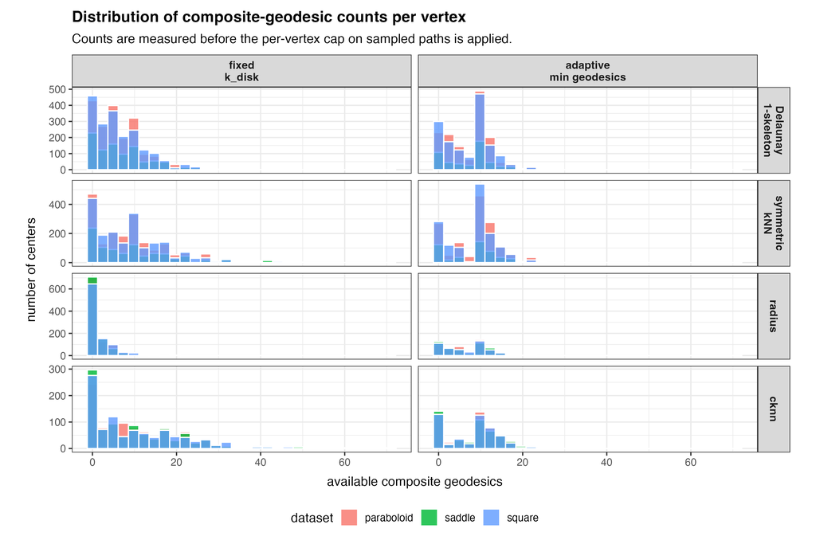

This figure is the main check on whether the adaptive radius rule succeeded. Compared with the fixed rule, the adaptive rule shifts the composite-geodesic count distribution away from zero and toward the requested minimum. Remaining low-count centers identify vertices where even the maximum allowed search size does not produce enough local path geometry.

## Nullity At A Fixed Numerical Tolerance

The formal null-space target for a degree-$d$ intrinsic polynomial annihilator on a two-dimensional domain is

$$\dim \ker(A)\approx \binom{d+2}{2}.$$

The next figure compares the estimated nullity at relative singular-value threshold $10^{-6}$ with the target values $3,6,10$. The dashed line marks perfect agreement.

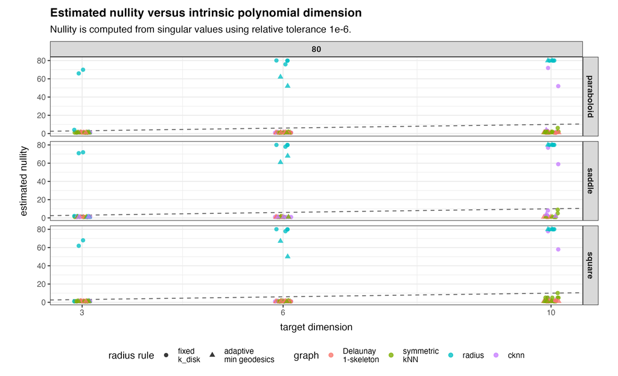

The fixed-threshold nullity still does not stabilize near $3,6,10$. The adaptive rule improves the most obvious underconstrained radius-graph failures for lower orders by forcing more composite geodesics into the operator, but it does not create the desired polynomial null space. Delaunay, cKNN, and symmetric kNN configurations remain mostly overconstrained, with estimated nullity near one. This answers the first nullity question in the negative for the present construction: path availability is necessary, but not sufficient, for recovering the expected intrinsic polynomial null-space dimension.

## Nullity Sensitivity

A single numerical tolerance can hide whether the singular spectrum contains a near-null plateau. We therefore also compute

$$\widehat{\dim\ker(A;\tau)}
= n - \#\{s_i(A): s_i(A)>\tau s_1(A)\}$$

for several relative tolerances $\tau$. A stable intrinsic null space would appear as a plateau near $3,6,10$ across a nontrivial tolerance range.

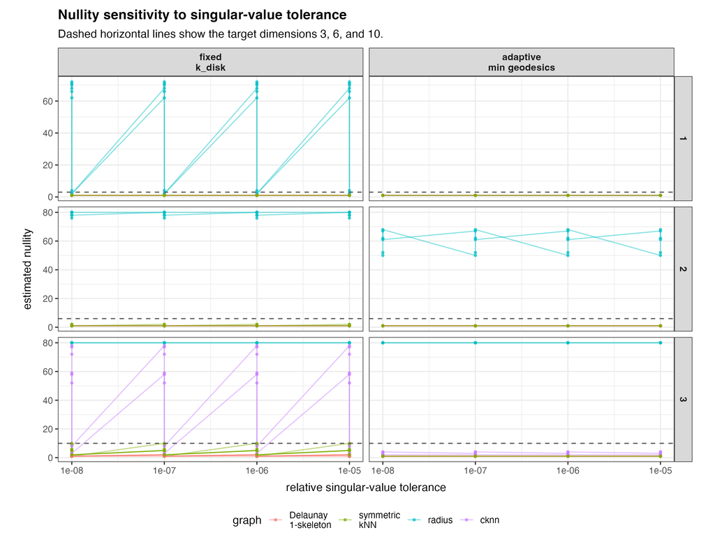

The sensitivity plot reinforces the fixed-tolerance result. There is no broad, stable plateau at the target dimensions. The adaptive rule reduces some large-nullity artifacts by adding rows where the fixed rule had too few paths, but the resulting spectrum still does not organize itself around the intrinsic dimensions $3,6,10$. This indicates that the current pathwise row stack is better viewed as a residual diagnostic than as a calibrated null-space construction.

## Polynomial Residual Ratios

Because exact numerical nullity is brittle on finite sampled graphs, we also evaluate sampled polynomial residuals directly. For a design matrix $P$, define

$$R(P)=\frac{\|AP\|_F}{\|P\|_F}.$$

For a degree-$d$ annihilator, residuals for intrinsic monomials of degree at most $d$ should be smaller than residuals for exact degree $d+1$ controls.

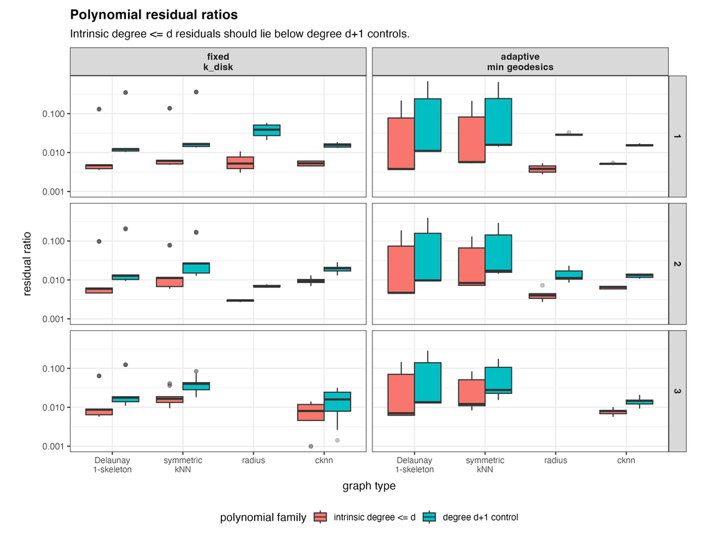

## Intrinsic Versus Ambient Structure On Quadrics

On a sampled quadric, the coordinates $(u,v)$ are intrinsic parameters, while $(X,Y,Z)$ are ambient coordinates. The intended operator should respond to polynomial behavior in intrinsic coordinates. For example, on a paraboloid, $Z$ is quadratic in $(u,v)$, so it should be treated differently by degree-1 and degree-2 annihilators. The following figure compares residuals for intrinsic and ambient function families.

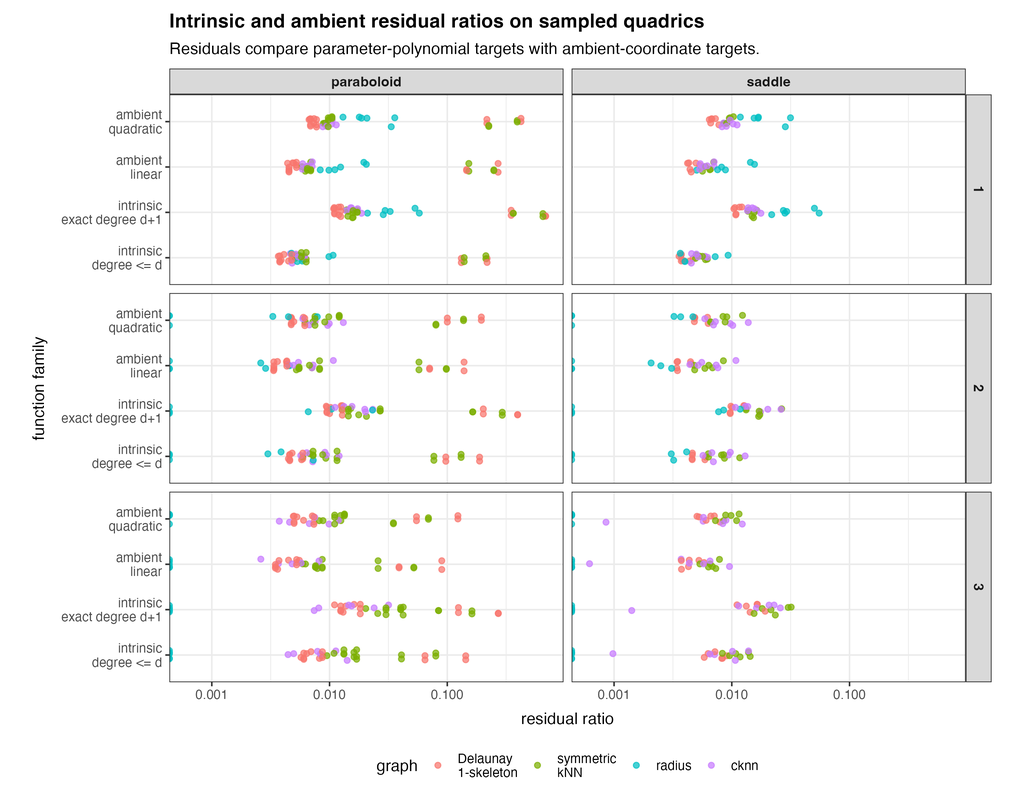

The quadric diagnostics suggest partial intrinsic behavior, but not yet a clean intrinsic polynomial annihilator. Intrinsic targets usually have lower residuals than degree-$d+1$ controls, and degree-2 operators improve on quadratic surface-coordinate behavior relative to degree-1 operators. However, the ambient and intrinsic families are not cleanly separated across all graphs. This is expected for a first pathwise construction because ambient coordinates and intrinsic parameters are strongly correlated on the sampled surfaces, especially at this sample size.

## Results Summary And Discussion

The experiments answer the main questions in a deliberately conservative way. The estimated nullity does **not** yet stabilize near $3,6,10$ for degrees $1,2,3$. The adaptive radius rule fixes one important construction problem: the median number of composite geodesics increases to the requested target for Delaunay, cKNN, and symmetric kNN graphs, and improves substantially for radius graphs. However, the expected polynomial nullity still does not emerge. This separates two issues that were previously entangled. The old fixed-radius rule could fail simply because too few paths were available; the new adaptive rule shows that even with adequate path availability, the current row stack is usually too constraining.

The quadric experiments also support a cautious interpretation. The operator shows some sensitivity to intrinsic polynomial structure in the parameter domain, but it does not yet sharply separate intrinsic polynomial behavior from ambient coordinate polynomial behavior. At the present sample sizes and graph densities, this is not surprising: the ambient coordinates are smooth functions of the intrinsic coordinates, and the current operator is built from one-dimensional path restrictions rather than from an explicit local tangent-coordinate model.

The graph comparison is informative. Delaunay 1-skeleton graphs are a useful geometric baseline because they maintain planar local structure and avoid some of the high-branching behavior of kNN graphs. Symmetric kNN and cKNN graphs give more composite paths, but they can also impose many overlapping constraints. Radius graphs are the least stable in this experiment because comparable disk sizes do not guarantee enough composite geodesics.

The immediate methodological conclusion is that the next version should not aim only to add more paths. The adaptive rule should remain part of the construction because it prevents path-starved local operators, but it must be paired with a path-selection or local-basis step whose goal is to preserve the expected polynomial null space while maintaining adequate coverage. The most useful next experiments are local row thinning by rank contribution, tangent-coordinate regression annihilators inside graph disks, and explicit comparison of row normalization and vertex normalization rules. The current report establishes the diagnostic framework needed to test those choices.

# Appendix

## Run Metadata

```r
result.path
```

```
## [1] "/Users/pgajer/current_projects/gflow/dev/graph-trend-filtering/reports/geodesic_annihilator_full.rds"
```

```r
 diagnostics$mode
```

```
## [1] "full"
```

```r
 diagnostics$created
```

```
## [1] "2026-05-17 09:17:37 EDT"
```

## Run Summary Table

```r
summary.table[, c("run.id", "dataset", "n", "seed", "graph.type", "degree",
                  "disk.k", "row.normalization", "vertex.normalization",
                  "analysis.group", "n.edges", "n.operator.rows",
                  "nullity.1e.6", "expected.nullity", "intrinsic.residual",
                  "control.residual", "status")]
```

```
##     run.id    dataset  n seed         graph.type degree disk.k
## 1        1     square 80    1 delaunay.1skeleton      1     18
## 2        2 paraboloid 80    1 delaunay.1skeleton      1     18
## 3        3     saddle 80    1 delaunay.1skeleton      1     18
## 4        4     square 80    2 delaunay.1skeleton      1     18
## 5        5 paraboloid 80    2 delaunay.1skeleton      1     18
## 6        6     saddle 80    2 delaunay.1skeleton      1     18
## 7        7     square 80    1      symmetric.knn      1     18
## 8        8 paraboloid 80    1      symmetric.knn      1     18
## 9        9     saddle 80    1      symmetric.knn      1     18
## 10      10     square 80    2      symmetric.knn      1     18
## 11      11 paraboloid 80    2      symmetric.knn      1     18
## 12      12     saddle 80    2      symmetric.knn      1     18
## 13      13     square 80    1             radius      1     18
## 14      14 paraboloid 80    1             radius      1     18
```

[output cut: 1237 more lines]

## Construction Summary Table

```r
aggregate(
  cbind(n.disk.vertices, n.composite.available, n.paths.used,
        selected.disk.k, n.operator.rows, used.mirror.proxy) ~
    dataset + graph.type + degree + disk.radius.rule + disk.k,
  data = vertex.table,
  FUN = function(z) if (is.logical(z)) mean(z) else stats::median(z)
)
```

```
##        dataset         graph.type degree        disk.radius.rule disk.k
## 1   paraboloid               cknn      1                 fixed.k     18
## 2       saddle               cknn      1                 fixed.k     18
## 3       square               cknn      1                 fixed.k     18
## 4   paraboloid delaunay.1skeleton      1                 fixed.k     18
## 5       saddle delaunay.1skeleton      1                 fixed.k     18
## 6       square delaunay.1skeleton      1                 fixed.k     18
## 7   paraboloid             radius      1                 fixed.k     18
## 8       saddle             radius      1                 fixed.k     18
## 9       square             radius      1                 fixed.k     18
## 10  paraboloid      symmetric.knn      1                 fixed.k     18
## 11      saddle      symmetric.knn      1                 fixed.k     18
## 12      square      symmetric.knn      1                 fixed.k     18
## 13  paraboloid               cknn      2                 fixed.k     18
## 14      saddle               cknn      2                 fixed.k     18
```

[output cut: 312 more lines]

## Nullity Table

```r
head(nullity.table, 40)
```

```
##       dataset  n seed         graph.type degree disk.k disk.radius.rule
## 1      square 80    1 delaunay.1skeleton      1     18          fixed.k
## 2      square 80    1 delaunay.1skeleton      1     18          fixed.k
## 3      square 80    1 delaunay.1skeleton      1     18          fixed.k
## 4      square 80    1 delaunay.1skeleton      1     18          fixed.k
## 5  paraboloid 80    1 delaunay.1skeleton      1     18          fixed.k
## 6  paraboloid 80    1 delaunay.1skeleton      1     18          fixed.k
## 7  paraboloid 80    1 delaunay.1skeleton      1     18          fixed.k
## 8  paraboloid 80    1 delaunay.1skeleton      1     18          fixed.k
## 9      saddle 80    1 delaunay.1skeleton      1     18          fixed.k
## 10     saddle 80    1 delaunay.1skeleton      1     18          fixed.k
## 11     saddle 80    1 delaunay.1skeleton      1     18          fixed.k
## 12     saddle 80    1 delaunay.1skeleton      1     18          fixed.k
## 13     square 80    2 delaunay.1skeleton      1     18          fixed.k
## 14     square 80    2 delaunay.1skeleton      1     18          fixed.k
```

[output cut: 149 more lines]

## Polynomial Score Table

```r
head(score.table, 40)
```

```
##       dataset  n seed         graph.type degree disk.k disk.radius.rule
## 1      square 80    1 delaunay.1skeleton      1     18          fixed.k
## 2      square 80    1 delaunay.1skeleton      1     18          fixed.k
## 3      square 80    1 delaunay.1skeleton      1     18          fixed.k
## 4      square 80    1 delaunay.1skeleton      1     18          fixed.k
## 5  paraboloid 80    1 delaunay.1skeleton      1     18          fixed.k
## 6  paraboloid 80    1 delaunay.1skeleton      1     18          fixed.k
## 7  paraboloid 80    1 delaunay.1skeleton      1     18          fixed.k
## 8  paraboloid 80    1 delaunay.1skeleton      1     18          fixed.k
## 9      saddle 80    1 delaunay.1skeleton      1     18          fixed.k
## 10     saddle 80    1 delaunay.1skeleton      1     18          fixed.k
## 11     saddle 80    1 delaunay.1skeleton      1     18          fixed.k
## 12     saddle 80    1 delaunay.1skeleton      1     18          fixed.k
## 13     square 80    2 delaunay.1skeleton      1     18          fixed.k
## 14     square 80    2 delaunay.1skeleton      1     18          fixed.k
```

[output cut: 190 more lines]

## Reproducibility Commands

```r
# Smoke run
GFLOW_GEO_ANNIHILATOR_MODE=smoke \
  Rscript dev/graph-trend-filtering/render_geodesic_annihilator_experiments.R

# Full run
GFLOW_GEO_ANNIHILATOR_MODE=full \
  Rscript dev/graph-trend-filtering/render_geodesic_annihilator_experiments.R
```